# The Global Water Access Gap

## Comparison Cloud

The below comparison cloud displays what words are commonly used in the text scraped from twitter while also having implications of “positive,” “trust,” or “joy.” Before diving into the detailed observations about the visualization itself, we lay out how the code below works. A comparison cloud enables users to accomplish two goals simultaneously: comparing the relative frequency of the use of certain words and classifying the most commonly used words into several categories based upon certain criteria. In order to craft a comparison cloud, however, it is necessary to transform the data into the form of matrix, whose column corresponds to certain categories (in this case, the sentiment) and whose row refers to each word by its name. In order to craft such a matrix, a lot of wrangling has been conducted to create a dataset whose row corresponds to words and column to each sentiment. If interested, analyze the commented code below.

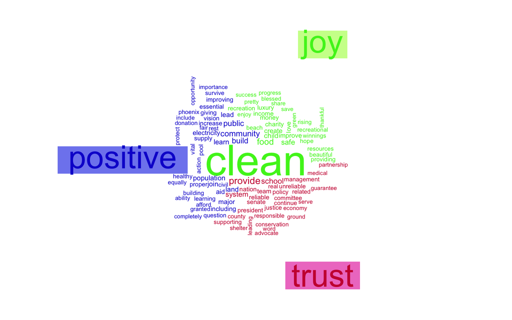

```r
# preliminary wranglings below
# first extract words with the connotations of interest
# tweet_sentiment = dataset used for sentiment analysis
pure_words <- tweets_sentiment %>%
  filter(sentiment == "positive" | sentiment == "trust" |
           sentiment == "joy") %>%
  # then collapse the rows so that each word only occupies a single row
  group_by(word) %>%
  summarize()
# now prepare the dataset to be joined with the dataset about the count of
# each word with the three focal sentiments
pure_words_copied <- pure_words %>%
  # let each word occupy three rows at the same time
  slice(rep(1:n(), each = 3)) %>%
  mutate(number = row_number()) %>%
  # list up all the sentiments of interest
  mutate(sentiment = case_when(number %% 3 == 1 ~ "positive",
                               number %% 3 == 2 ~ "trust",
                               number %% 3 == 0 ~ "joy")) %>%
  select(word, sentiment)
# the below dataset is about the count of each word with the three connotations
# of interest
comparison_words_prep <- tweets_sentiment %>%
  # extract those with the three sentiments of innterest
  filter(sentiment == "positive" | sentiment == "trust" |
           sentiment == "joy") %>%
  # and count the frequency
  group_by(word, sentiment) %>%
  summarize(N = n())
comparison_words_prep_2 <- pure_words_copied %>%
  # join the dataset with the data about the count (used for the bar)
  left_join(comparison_words_prep, by = c("word", "sentiment")) %>%
  # if some words do not imply certain sentiments, it will be reflected as
  # N/A values, so turn it into 0
  mutate(count = case_when(is.na(N) ~ 0,
                           TRUE ~ as.numeric(N))) %>%
  select(word, sentiment, count)
# one last step to make each column refer to each sentiment
comparison_words_prep_3 <- comparison_words_prep_2 %>%
  spread(key = sentiment, value = count)
# the below code translates the data frame into a matrix, and each row name of
# the matrix should correspond to the word
comparison_words <- comparison_words_prep_3 %>%
  select(-word) %>%
  as.matrix()
rownames(comparison_words) <- comparison_words_prep_3$word

# create the comparison cloud
colors1 <- c("#48F11F", "#1226D2", "#CB0A3E")
colors2 <- c("#CCFF99", "#7F88EF", "#EF7FCA")
comparison.cloud(comparison_words, max.words = 100,
                 random.order = FALSE,
                 colors = colors1,
                 title.colors = colors1,
                 title.bg.colors = colors2)
```